## **ABEV3**

Hoje foi um dia especial para o mercado brasileiro, especialmente para as ações que lideraram a charges positivas! Na minha análise, é claro que o ABEV3 (Anheuser-Busch InBev) foi uma das estrelas do show. Com um fechamento de R$ 12,58, essa ação teve uma variação de 0,479% em relação ao dia anterior. Isso significa que os investidores estão começando a perceber o valor da empresa e estão mais dispostos a comprar, levando ao aumento do preço.E não é só isso, amigos! A variável mensal do ativo está crescendo com uma taxa de 3,54%, mostrando que a tendência positiva pode ser um sinal de que a Anheuser-Busch InBev está se recuperando após um período mais difícil. Já a variância anual é de 2,95%, o que é um indicador positivo para os investidores.Agora, é importante lembrar que a Anheuser-Busch InBev tem uma história de crescimento e dividendos consistentes, o que pode atrair mais investimentos. Além disso, a empresa tem uma presença global e uma variedade de marcas fortes, como Skol e Brahma, o que pode trazer benefícios para os acionistas.Em resumo, o ABEV3 foi um dos ganhadores do dia, com uma variação positiva e uma tendência atraente. Isso não significa que os investidores devem se precipitar em comprar, mas sim que é importante observar as tendências e considerar a longo prazo quando investir na Anheuser-Busch InBev. Veja a seguir o gráfico do desempenho ao longo do tempo.

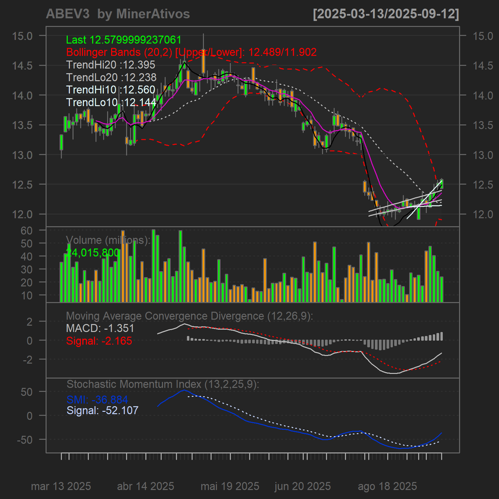

[figure not shown]